# Assignment_1

1/23/2022

First, load in the required libraries and the data.

```r
library(tidyverse)
bc_data = read.csv("bcdata.csv")
```

### Question #1

Construct a table providing summaries of the quantitative features of the dataset.Summaries should include the mean, median, minimum value, and maximum value.

```r
summary_data = summary(bc_data)
str(summary_data)
```

```
##  'table' chr [1:6, 1:10] "Min.   :24.0  " "1st Qu.:45.0  " "Median :56.0  " ...
##  - attr(*, "dimnames")=List of 2
##   ..$ : chr [1:6] "" "" "" "" ...
##   ..$ : chr [1:10] "     Age" "     BMI" "   Glucose" "   Insulin" ...
```

```r
as.data.frame.matrix(summary_data) %>%
  knitr::kable()
```

|  | Age | BMI | Glucose | Insulin | HOMA | Leptin | Adiponectin | Resistin | MCP.1 | Classification |
| --- | --- | --- | --- | --- | --- | --- | --- | --- | --- | --- |
| X | Min. :24.0 | Min. :18.37 | Min. : 60.00 | Min. : 2.432 | Min. : 0.4674 | Min. : 4.311 | Min. : 1.656 | Min. : 3.210 | Min. : 45.84 | Min. :1.000 |
| X.1 | 1st Qu.:45.0 | 1st Qu.:22.97 | 1st Qu.: 85.75 | 1st Qu.: 4.359 | 1st Qu.: 0.9180 | 1st Qu.:12.314 | 1st Qu.: 5.474 | 1st Qu.: 6.882 | 1st Qu.: 269.98 | 1st Qu.:1.000 |
| X.2 | Median :56.0 | Median :27.66 | Median : 92.00 | Median : 5.925 | Median : 1.3809 | Median :20.271 | Median : 8.353 | Median :10.828 | Median : 471.32 | Median :2.000 |
| X.3 | Mean :57.3 | Mean :27.58 | Mean : 97.79 | Mean :10.012 | Mean : 2.6950 | Mean :26.615 | Mean :10.181 | Mean :14.726 | Mean : 534.65 | Mean :1.552 |
| X.4 | 3rd Qu.:71.0 | 3rd Qu.:31.24 | 3rd Qu.:102.00 | 3rd Qu.:11.189 | 3rd Qu.: 2.8578 | 3rd Qu.:37.378 | 3rd Qu.:11.816 | 3rd Qu.:17.755 | 3rd Qu.: 700.09 | 3rd Qu.:2.000 |
| X.5 | Max. :89.0 | Max. :38.58 | Max. :201.00 | Max. :58.460 | Max. :25.0503 | Max. :90.280 | Max. :38.040 | Max. :82.100 | Max. :1698.44 | Max. :2.000 |

### Question 2

Recode BMI into the WHO-defined categories

```r
new_data = bc_data %>%
  mutate(
    BMI = case_when(
    BMI < 16.5 ~ "Severely underweight",
    BMI > 16.5 & BMI < 18.5 ~ "Underweight",
    BMI >= 18.5 & BMI <= 24.9 ~ "Normal weight",
    BMI >= 25 & BMI <= 29.9 ~ "Overweight",
    BMI >= 30 & BMI <= 34.9 ~ "Obsesity class I",
    BMI >= 35 & BMI <=39.9 ~ "Obesity class II",
    TRUE ~ "Obesity class III")
    ) %>%
  mutate(
    BMI = factor(BMI, levels = c("Severely underweight", "Underweight", "Normal weight", "Overweight", "Obsesity class I", "Obesity class II", "Obesity class III"))
  )

str(new_data$BMI)
```

```
##  Factor w/ 7 levels "Severely underweight",..: 3 3 3 3 3 3 3 3 3 3 ...
```

### Question 3

Create a bar chart showing the proportion of breast cancer cases and controls within each BMI category.

#### Proportion of Breast Cancer

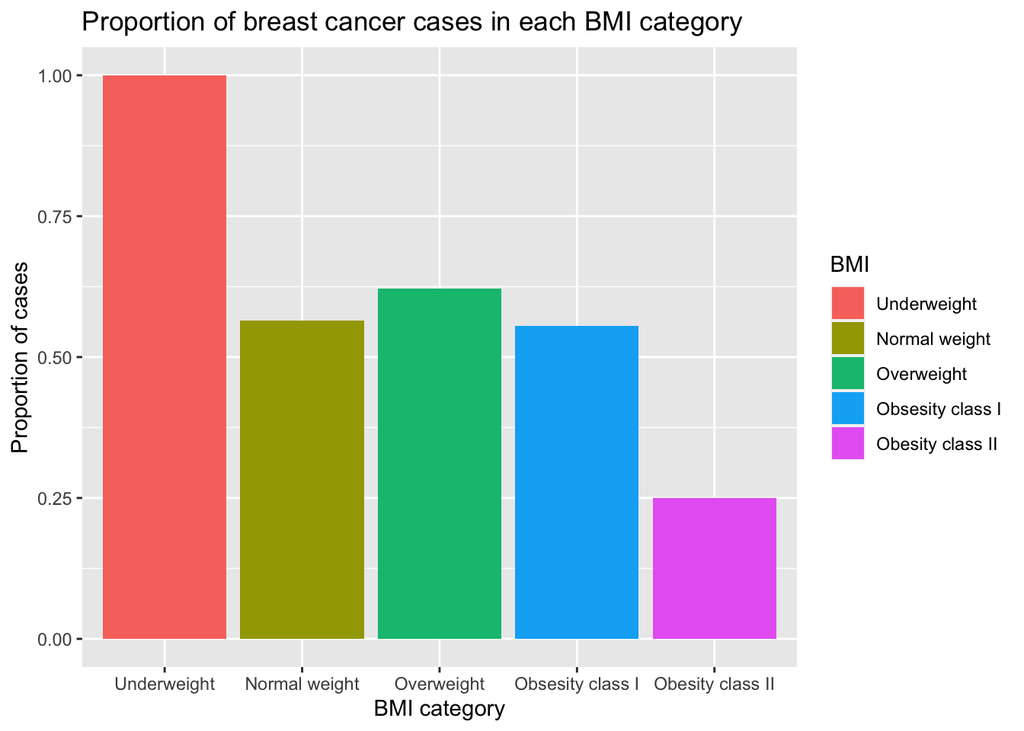

```r
new_data2 =
new_data %>%
  group_by(BMI) %>%
  summarize(
    control = sum(Classification == 1) / n(),
    bc = sum(Classification == 2)/ n()
  ) %>%
  ggplot(aes(x = BMI, y = bc, fill = BMI)) +
  geom_bar(stat = "identity") +
  ggtitle("Proportion of breast cancer cases in each BMI category") +
  xlab("BMI category") + ylab("Proportion of cases")

new_data2
```

#### Proportion of Control

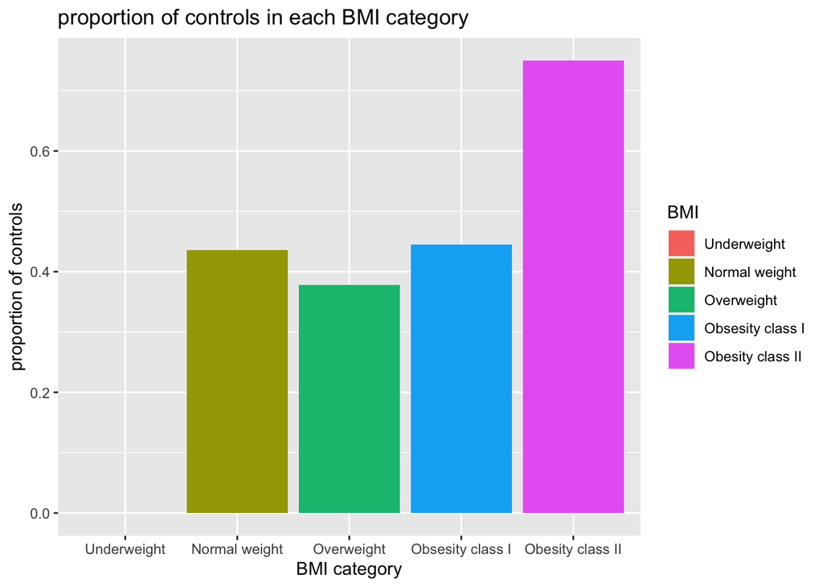

```r
new_data3 =
new_data %>%
  group_by(BMI) %>%
  summarize(
    control = sum(Classification == 1) / n(),
    bc = sum(Classification == 2)/ n()
  ) %>%
  ggplot(aes(x = BMI, y = control, fill = BMI)) +
  geom_bar(stat = "identity") +
  ggtitle("proportion of controls in each BMI category") +
  xlab("BMI category") + ylab("proportion of controls")

new_data3
```

### Question 4

Construct a **logistic** regression model:

- outcome: breast cancer classification
- independent variables: glucose, HOMA-IR, leptin, BMI (continuous), age

Fill in the beta estimate and 95% confidence interval associated with a 1-unit change in HOMA-IR.

```r
model_data = bc_data %>%
  janitor::clean_names() %>%
  mutate(
    classification = ifelse(classification == 1, 0, 1)
  )

logistic_model = glm(classification ~ glucose + homa + leptin + bmi + age, data = model_data, family = "binomial")

summary(logistic_model)
##
## Call:
## glm(formula = classification ~ glucose + homa + leptin + bmi +
##     age, family = "binomial", data = model_data)
##
## Deviance Residuals:
##     Min       1Q   Median       3Q      Max
## -2.2944  -0.8901   0.1308   0.8084   2.1371
##
## Coefficients:
##              Estimate Std. Error z value Pr(>|z|)
## (Intercept) -3.626065   2.355177  -1.540 0.123654
## glucose      0.081699   0.023526   3.473 0.000515 ***
## homa         0.273882   0.171976   1.593 0.111259
## leptin      -0.008574   0.015783  -0.543 0.586979
## bmi         -0.104261   0.056642  -1.841 0.065668 .
## age         -0.022881   0.014377  -1.592 0.111496
## ---
## Signif. codes:  0 '***' 0.001 '**' 0.01 '*' 0.05 '.' 0.1 ' ' 1
##
## (Dispersion parameter for binomial family taken to be 1)
##
##     Null deviance: 159.57  on 115  degrees of freedom
## Residual deviance: 120.81  on 110  degrees of freedom
## AIC: 132.81
##
## Number of Fisher Scoring iterations: 6
confint(logistic_model)
##                   2.5 %      97.5 %
## (Intercept) -8.54138756 0.754487774
## glucose      0.03956613 0.132397841
## homa        -0.02555240 0.653222623
## leptin      -0.04019445 0.022416142
## bmi         -0.21944692 0.004398024
## age         -0.05192184 0.004856327
```

For every one unit change in HOMA-IR, the log odds of having breast cancer increases by **0.2738822** (95% CI: -0.025, 0.653).

https://stats.oarc.ucla.edu/r/dae/logit-regression/

### Question 5

Construct a **linear** regression model:

- outcome: insulin
- independent variables: BMI (continuous), age, glucose

Fill in the beta estimate and 95% confidence interval associated with a 1-unit change in age.

```r
linear_model = lm(insulin ~ bmi + age + glucose, data = model_data)
summary(linear_model)
##
## Call:
## lm(formula = insulin ~ bmi + age + glucose, data = model_data)
##
## Residuals:
##     Min      1Q  Median      3Q     Max
## -22.161  -4.359  -2.118   2.124  46.269
##
## Coefficients:
##              Estimate Std. Error t value Pr(>|t|)
## (Intercept) -13.49576    5.85941  -2.303   0.0231 *
## bmi           0.14969    0.16382   0.914   0.3628
## age          -0.05402    0.05194  -1.040   0.3005
## glucose       0.22982    0.03752   6.126 1.37e-08 ***
## ---
## Signif. codes:  0 '***' 0.001 '**' 0.01 '*' 0.05 '.' 0.1 ' ' 1
##
## Residual standard error: 8.731 on 112 degrees of freedom
## Multiple R-squared:  0.2675, Adjusted R-squared:  0.2479
## F-statistic: 13.64 on 3 and 112 DF,  p-value: 1.207e-07
confint(linear_model)
##                   2.5 %      97.5 %
## (Intercept) -25.1054353 -1.88608318
## bmi          -0.1748942  0.47427491
## age          -0.1569321  0.04888876
## glucose       0.1554864  0.30414939
```

For every one year increase in age, the insulin decreases by **-0.0540217** microU/mL (95% CI: -0.157, 0.048).